# Kaggle: Titanic EDA

Chelsea Lee

April 23, 2018

# Outline

Read in dataset and load libraries

Handling Missing Data

Remove Missing data

Imputing Missing data

Factorizing Categorical Variables for future EDA visualizations

Ticket

Fare

Sex and Companion

Parch and Sibsp

Make hasCompanions Feature

Create isSmallFamily Variable

Embarked

Embarked and Fare_cat

Age

Name

Final Checks

# Read in Dataset and Load Libraries

```r
setwd("C:/Users/Chelsea Lee/Dropbox/Kaggle Stuff/Titanic")

library(ggplot2)
library(dplyr)
library(missMDA)
library(dummies)
library(stringr)
train <- read.csv("train.csv", stringsAsFactors = F )
test <- read.csv("test.csv", stringsAsFactors = F)

train$isTrain <- 1
test$isTrain <- 0
test$Survived <- NA
```

```r
#combine all
all <- rbind(train, test)
head(all)
```

```
##   PassengerId Survived Pclass
## 1           1        0      3
## 2           2        1      1
## 3           3        1      3
## 4           4        1      1
## 5           5        0      3
## 6           6        0      3
##                                                  Name    Sex Age SibSp
## 1                             Braund, Mr. Owen Harris   male  22     1
## 2 Cumings, Mrs. John Bradley (Florence Briggs Thayer) female  38     1
## 3                              Heikkinen, Miss. Laina female  26     0
## 4        Futrelle, Mrs. Jacques Heath (Lily May Peel) female  35     1
## 5                            Allen, Mr. William Henry   male  35     0
## 6                                    Moran, Mr. James   male  NA     0
##   Parch           Ticket    Fare Cabin Embarked isTrain
## 1     0        A/5 21171  7.2500              S       1
## 2     0         PC 17599 71.2833   C85        C       1
## 3     0 STON/O2. 3101282  7.9250              S       1
## 4     0           113803 53.1000  C123        S       1
## 5     0           373450  8.0500              S       1
## 6     0           330877  8.4583              Q       1
```

# Handling Missing Data

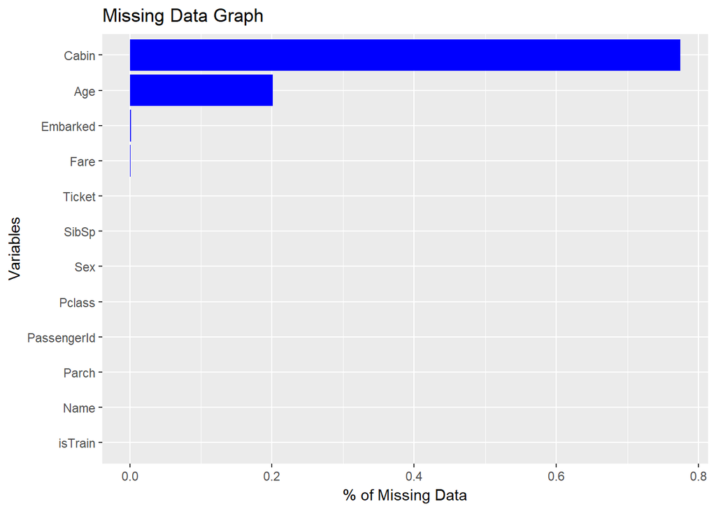

```r
#label which entry is NA, then find the mean of all columns
#(true/false can be regarded as 1/0)

#find all character columns
character_col <- unlist(lapply(all, is.character))
#find indexes of columns that are character
char_ind <- which(character_col)

#loop through all character columns and change "" to NA
for (char_col in char_ind){
  regexp <- all[,char_col] == ""
  all[regexp,char_col] <- NA
}

#Do not look at target variable. Testing is missing Survived column.
missing_dat <- colMeans(is.na(all[,colnames(all)!= "Survived"]))
missing_dat <- sapply(missing_dat, function(x){round(x,4)})
missing_dat <- as.data.frame(missing_dat)
colnames(missing_dat)[1] <- "n"
missing_dat$var <- rownames(missing_dat)

#reset row indexes
rownames(missing_dat) <- NULL

#Bar graph of missing data
ggplot(missing_dat, aes(x = reorder(var, n), y = n)) +
    geom_bar(stat = "identity", fill = "blue") +
    xlab("Variables") +
    ylab("% of Missing Data") +
    ggtitle("Missing Data Graph") +
    coord_flip()
```

From the above graph, we see only four variables have missing data. We could impute Age, Embarked, and Fare. Cabin has too much missing data (>75%), so this variable will be discarded.

# Remove Missing Data

```r
#If column has more than 50% data missing, remove
missing_dat[which(missing_dat$n > 0.5),] #We are dropping cabin!
```

```
##         n   var
## 10 0.7746 Cabin
```

```r
good_col <- c(missing_dat$var[which(missing_dat$n  < 0.5)],"Survived")
all <- all[,good_col]
```

# Imputing Missing Data

```r
#Multiple imputation on quantitative data
all_numeric <- all[,!(colnames(all) %in% c("PassengerId", "Name", "TicketNumber",
                                         "Sex", "Ticket", "Embarked"))]

#Estimate the number of dimensions to compute
nbdim <- estim_ncpPCA(all_numeric)
num.imputed <- MIPCA(all_numeric, ncp = nbdim$ncp, nboot = 1000)

#Create df of imputed values
num_imputed <- num.imputed$res.MI[[1]]

#Extract imputed values and use it in dataset.
all$Age <- num_imputed$Age
all$Fare <- num_imputed$Fare

##No need to impute Embarked, the only categorical variable with missing data, becasue there are only two missing values
#Impute with most common port
print("Frequency Table of Ports")
```

```
## [1] "Frequency Table of Ports"
```

```r
table(all$Embarked)
```

```
##
##   C   Q   S
## 270 123 914
```

```r
#change NA to most common port
all$Embarked[is.na(all$Embarked)] <- "S"

#Don't look at target variable
missing_dat_preclean <- colMeans(is.na(all[colnames(all) != "Survived" ]))
missing_dat_preclean
```

```
## PassengerId      Pclass        Name         Sex         Age       SibSp
##           0           0           0           0           0           0
##       Parch      Ticket        Fare    Embarked     isTrain
##           0           0           0           0           0
```

```r
paste("Total percentage of missing data:",sum(missing_dat_preclean), "%")
```

```
## [1] "Total percentage of missing data: 0 %"
```

0%! Let’s go do some EDA!

# Factorizing Categorical Variables for future EDA visualizations

Also, change 0/1 in target variable to “Died”/“Survived”. Change back to numerics for modeling after EDA

```r
#####Factorizing variables
all$Survived <- ifelse(all$Survived == 1, "Survived", "Died")
shouldBeCategorical <- c("Pclass", "Embarked", "Survived", "Sex")
for(col in shouldBeCategorical) {
  all[[col]] <- as.factor(all[[col]])
}

#print structure to double check if variables are stored as char, int, or factor appropriately
str(all)
```

```
## 'data.frame':    1309 obs. of  12 variables:
##  $ PassengerId: int  1 2 3 4 5 6 7 8 9 10 ...
##  $ Pclass     : Factor w/ 3 levels "1","2","3": 3 1 3 1 3 3 1 3 3 2 ...
##  $ Name       : chr  "Braund, Mr. Owen Harris" "Cumings, Mrs. John Bradley (Florence Briggs Thayer)" "Heikkinen, Miss. Laina" "Futrelle, Mrs. Jacques Heath (Lily May Peel)" ...
##  $ Sex        : Factor w/ 2 levels "female","male": 2 1 1 1 2 2 2 2 1 1 ...
##  $ Age        : num  22 38 26 35 35 ...
##  $ SibSp      : int  1 1 0 1 0 0 0 3 0 1 ...
##  $ Parch      : int  0 0 0 0 0 0 0 1 2 0 ...
##  $ Ticket     : chr  "A/5 21171" "PC 17599" "STON/O2. 3101282" "113803" ...
##  $ Fare       : num  7.25 71.28 7.92 53.1 8.05 ...
##  $ Embarked   : Factor w/ 3 levels "C","Q","S": 3 1 3 3 3 2 3 3 3 1 ...
##  $ isTrain    : num  1 1 1 1 1 1 1 1 1 1 ...
##  $ Survived   : Factor w/ 2 levels "Died","Survived": 1 2 2 2 1 1 1 1 2 2 ...
```

# Ticket

There are alpha numeric codes in ticket and varying digit lengths. Investigate if there’s a correlation between digit length of ticket number and survival

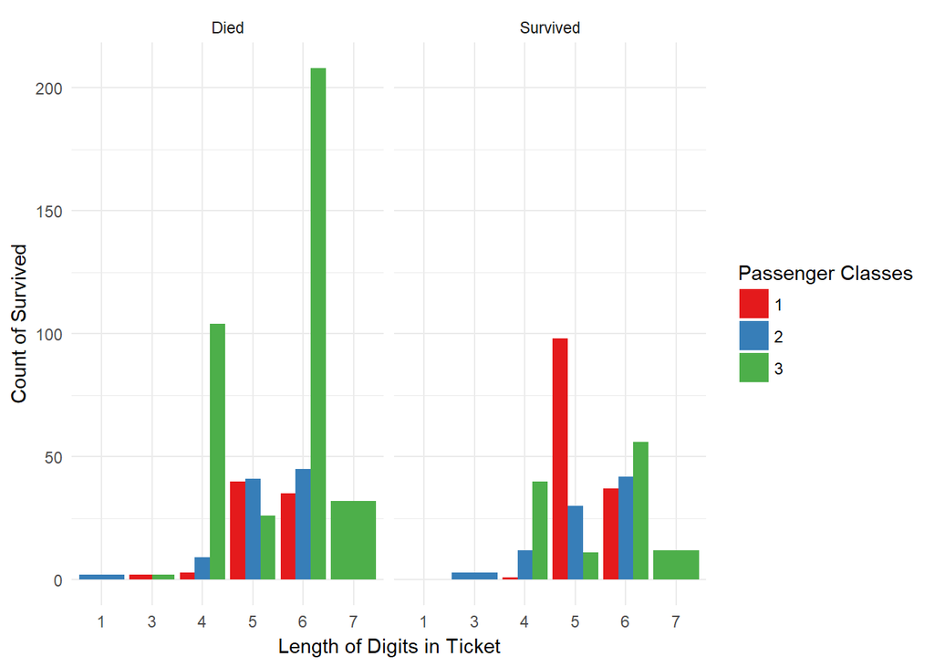

```r
#make TicketNumber feature
all$TicketNumber <- gsub("([A-Za-z///.0-9]+) ","",all$Ticket)

#make TicketLen feature
all$TicketLen <- nchar(all$TicketNumber)

#make frequency table of ticket number digit lengths and passenger class
ticketnumlen_pclass <- all[all$isTrain == 1,] %>%
  group_by(TicketLen, Pclass) %>%
  count(Survived)

#Graph
ggplot(ticketnumlen_pclass, aes(x =factor(TicketLen), y = n, fill = factor(Pclass))) +
  geom_bar(stat = "identity", position = "dodge") +
  scale_fill_brewer(palette = "Set1") +
  facet_grid(~Survived) +
  theme_minimal() +
  xlab("Length of Digits in Ticket") +
  ylab("Count of Survived") +
  guides(fill=guide_legend(title="Passenger Classes"))
```

Seems that third class passengers with four or 6 digits long have a higher chance of dying. Whereas, first class passengers with 5 digits long have a higher chance of survival.